# Final Project

Rachel Prokopius

3/31/2020

# Introduction

[output not shown]

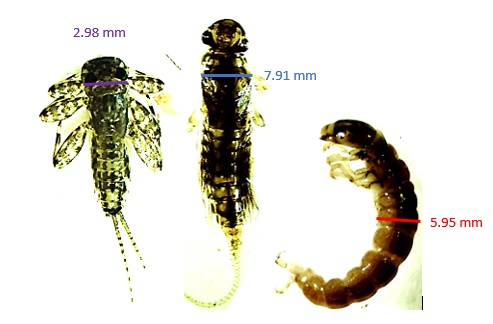

Image 1. Image illustrating the unique morphologies of different macroinvertebrate families. Images taken at 1x power with a Motic 3.0 Camera. Size bars for each macroinvertebrate are included. Macroinvertebrate familes from left to right: Ephemeroptera, Plecoptera, Trichoptera

[output not shown]

# Methods

[output not shown]

[figure not shown]

Figure 1. Maps of study area in Värmland, Sweden. Maps supplied by http://www.geographicguide.com/europe-maps/sweden.htm and https://en.wikipedia.org/wiki/V%C3%A4rmland_County

[figure not shown]

Figure 2. Maps of study area in Northern Kentucky.Red “NKU” symbolizes the university. Maps supplied by https://www.sporcle.com/games/Matt/find_the_states and Google Maps

[output not shown]

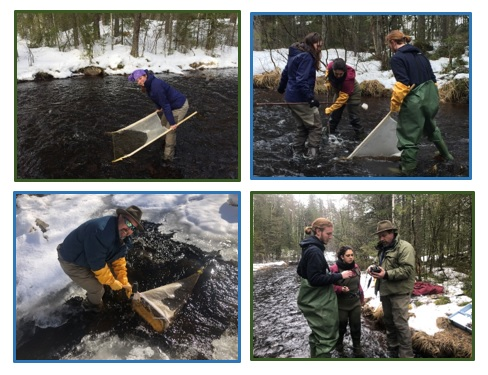

Image 2. Research at the Ranån study site in Sweden. Upper left: holding kicknet for catching macroinvertebrates. Upper right: research students collecting macroinvertebrates. Lower left: setting up the drift net system. Lower right: learning to use field equipment

[output not shown]

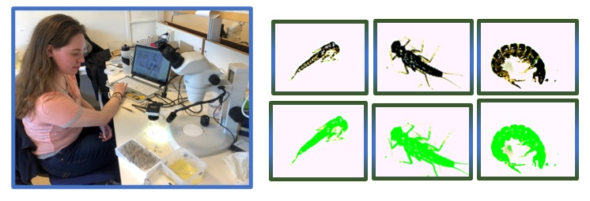

Image 3. Analysis of macroinvertebrates in the lab. Left: setup of imaging and data collection from macroinvertebrates. Right: Surface area of macroinvertebrates highlighted in green and calculated in square mm by the Motic 3.0 Imaging software.

[output not shown]

# Results

[output not shown]

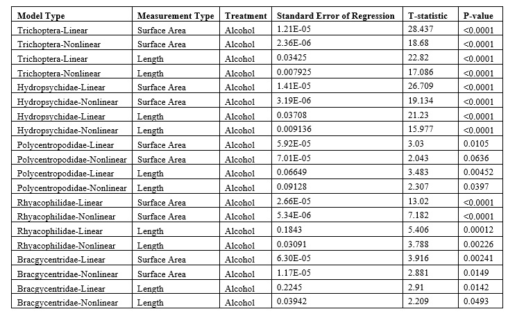

Table 1. Summary table of statistics for linear and nonlinear models for surface area and length to mass relationships for individual Trichoptera families

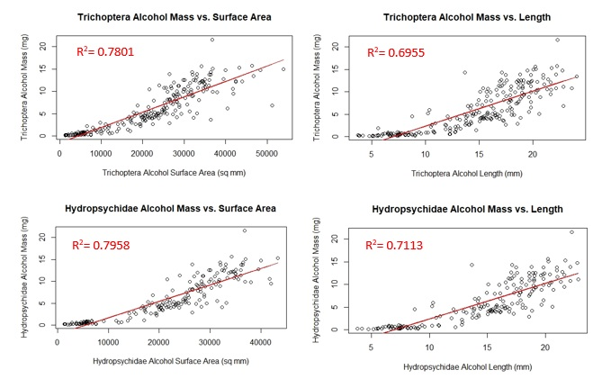

Figure 3. Linear surface area and length to mass relationships for the Trichoptera Order and the Hydropsychidae Family

```
      Side-by-side graphs of surface area and length to mass relationships for the Trichoptera Order and the Hydropsychidae Family, the family of caddisfly larvae most prominent in the field collections at the Ranån field site in Sweden, are included (Figure 4).
```

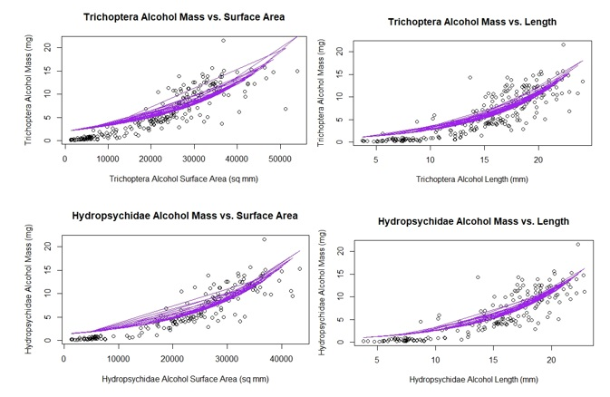

Figure 4. Nonlinear surface area and length to mass relationships for the Trichoptera Order and the Hydropsychidae Family

# Discussion

[output not shown]

# Literature Cited

Brodmann, P. A., and H. U. Reyer. 1999. Nestling provisioning in water pipits (*Anthus spinoletta*): do parents go for specific nutrients or profitable prey? Oecologia 120:506–514.

Cummins KW, Wuycheck JC. 1971. Caloric equivalents for investigation in ecological energetics. Mitt Int Vercin Limnol 18:1-158.

Eklöf J, Austin Å, Bergström, Donadi, Eriksson BDHK, Hansen J, Sunblad G. 2017. Size matters: relationships between body size and body mass of common coastal, aquatic invertebrates in the Baltic Sea. PeerJ 5, e2906.

Gilinsky E. 1984. The role of fish predation and spatial heterogeneity in determining benthic community structure. Ecology 65(2):455-68.

Helmus HR, Mercado-Silva N, Zanden MJV. 2013. Subsidies to predators, apparent competition and the phylogenetic structure of prey communities. Oecologia 173(3):997-1007.

Johnston TA, Cunjak RA. 1999. Dry mass-length relationships for benthic insects: a review with new data from Catamaran Brook, New Brunswick, Canada. Freshwater Biol 41:653-74.

Mährlein M, Pätzig M, Brauns M, Dolman AM. 2016. Length-mass relationships for lake macroinvertebrates corrected for back-transformation and preservation effects. Hydrobiologia 768:37-50.

Oertli B. 1993. Leaf litter processing and energy flow through macroinvertebrates in a woodland pond (Switzerland). Oecologia 96:466-77.

Paavo B, Ziegelmeyer A, Lavric E, Probert K. 2008. Morphometric correlations and body mass regressions for *Armandia maculate*, *Aglaophamus macrourna* (Polychaeta) and *Zethalia zelandica* (Gastropoda). New Zeal J Mar Fresh 42:85-91.

Pond GJ, Fritz KM, Johnson BR. 2016. Macroinvertebrate and organic matter export from headwater tributaries of a Central Appalachian stream. Hydrobiologia 779:75-91.

Sample BE, Cooper RJ, Greer RD, Whitmore RC. 1993. Estimation of insect biomass by length and width. The American Midland Naturalist 129(2):234-40.

Smock LA. 1980. Relationships between body size and biomass of aquatic insects. Freshwater Biol 10:375-83.

Turesson H, Persson A, Brönmark C. 2002. Prey selection of piscivorous pikeperch (*Stizostedion lucioperca*) includes active prey choice. Ecol Freshw Fish 11:223-33.

Velghe K, Gregory-Eaves I. 2013. Body size is a significant predictor of congruency in species richness patterns: a meta-analysis of aquatic studies. Plos One 8(2).

Wilt LM, Grebmeier JM, Miller TJ, Cooper LW. 2014. Caloric content of Chukchi Sea benthic invertebrates: modeling spatial and environmental variation. Deep-Sea Res Pt II 102:97-106.

Zhao X, Fox MG, Miller TJ, Lasenby DC. 2005. Effect of prey density, prey mobility and habitat structure on size selection and consumption of amphipods by a benthic feeding fish. Arch Hydrobiologia 165(2):269-88.